# Initial population sizes

```
## [1] "The proportion of exposed animals against the number of animals in the initial population"
```

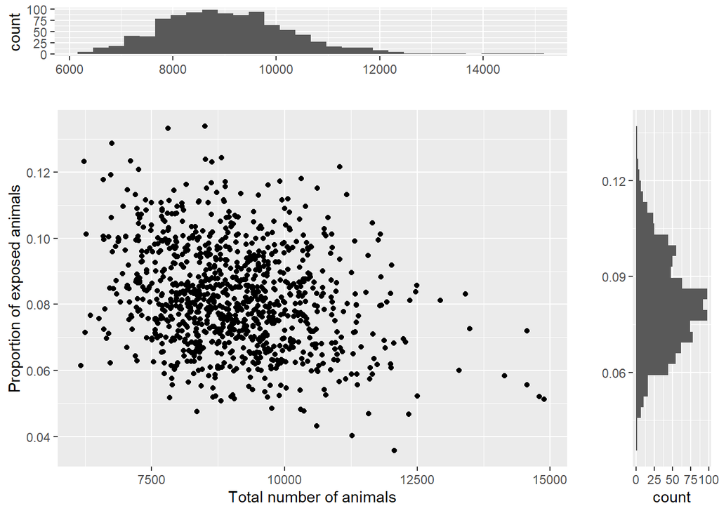

```
## [1] "The following plots are for Scoe"
## [1] "The spatial density for Scoe"
```

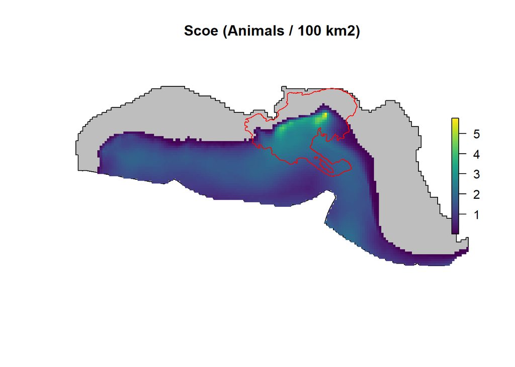

```
## [1] "The number of exposed animals against the number of animals in the initial population"
```

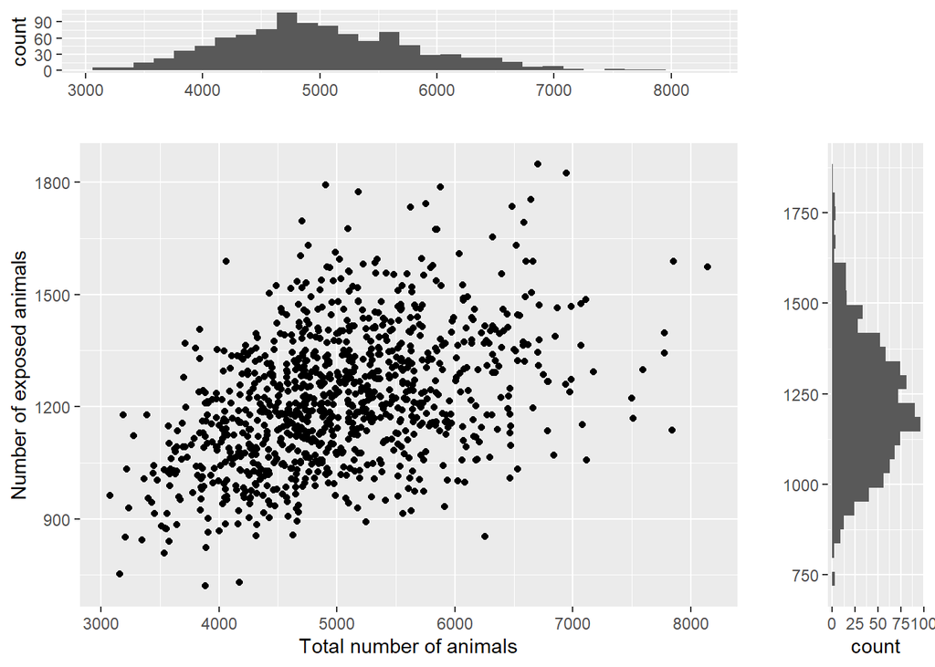

```
## [1] "The proportion of exposed animals against the number of animals in the initial population"
```

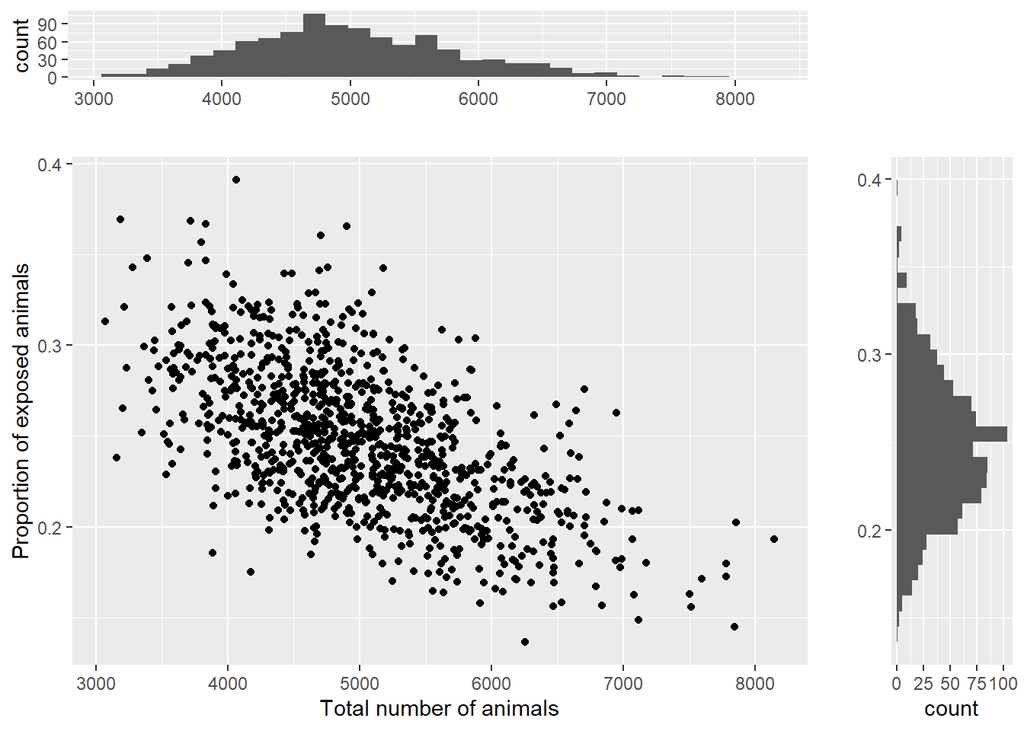

```
## [1] "The following plots are for Sfro"
## [1] "The spatial density for Sfro"
```

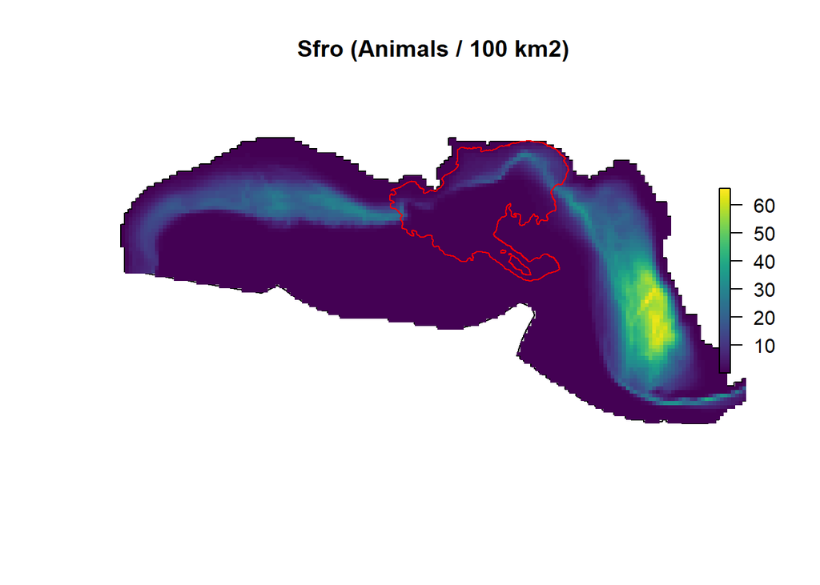

```
## [1] "The number of exposed animals against the number of animals in the initial population"
```

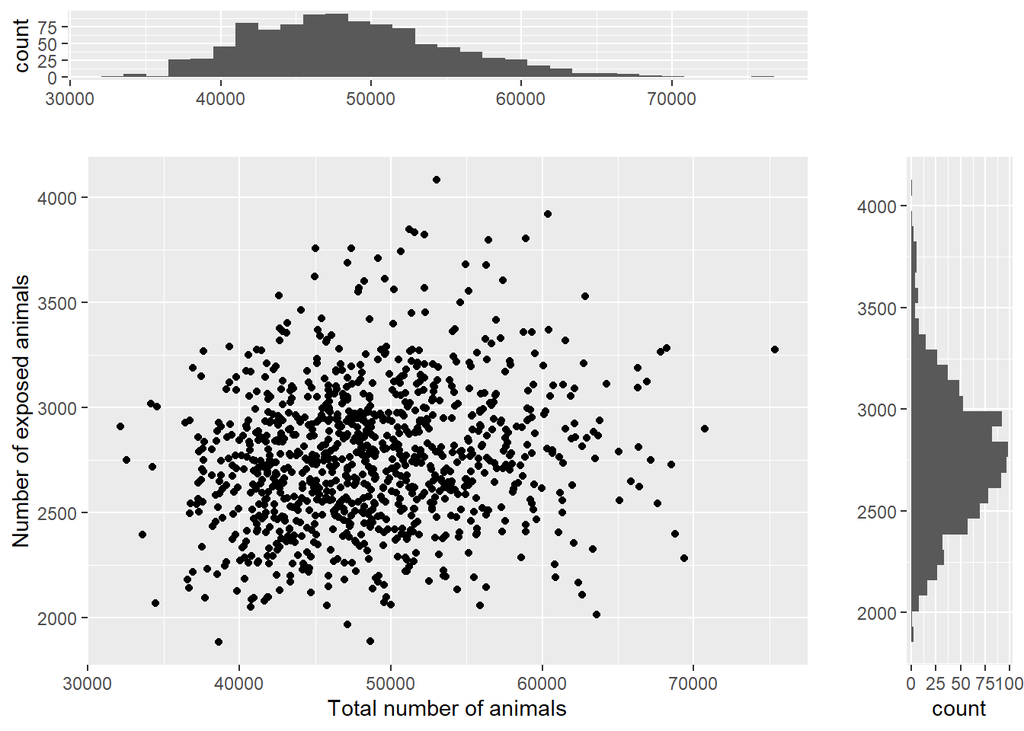

```
## [1] "The proportion of exposed animals against the number of animals in the initial population"
```

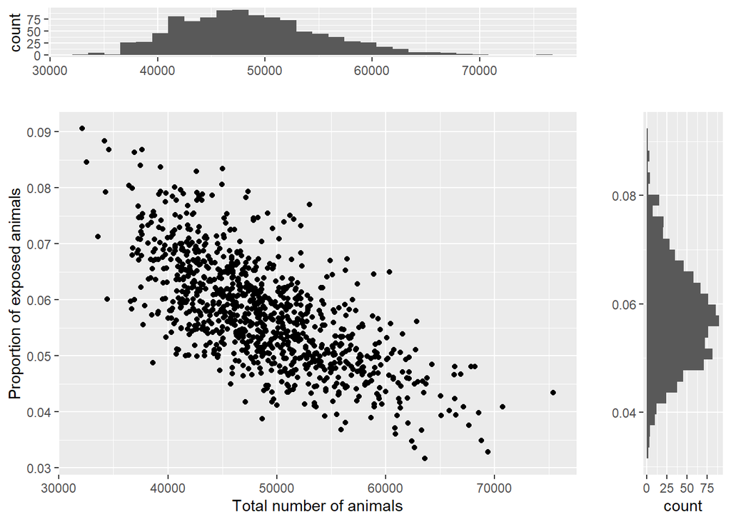

```
## [1] "The following plots are for Slon"
## [1] "The spatial density for Slon"
```

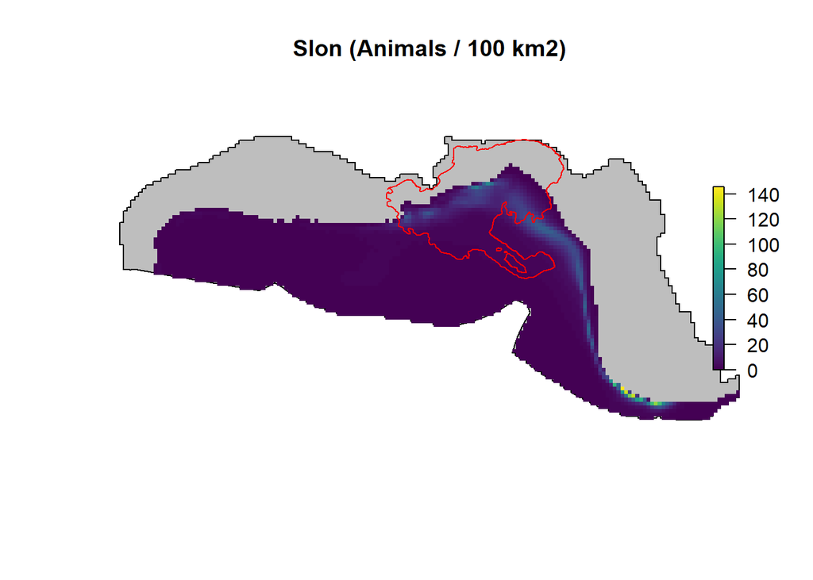

```
## [1] "The number of exposed animals against the number of animals in the initial population"
```

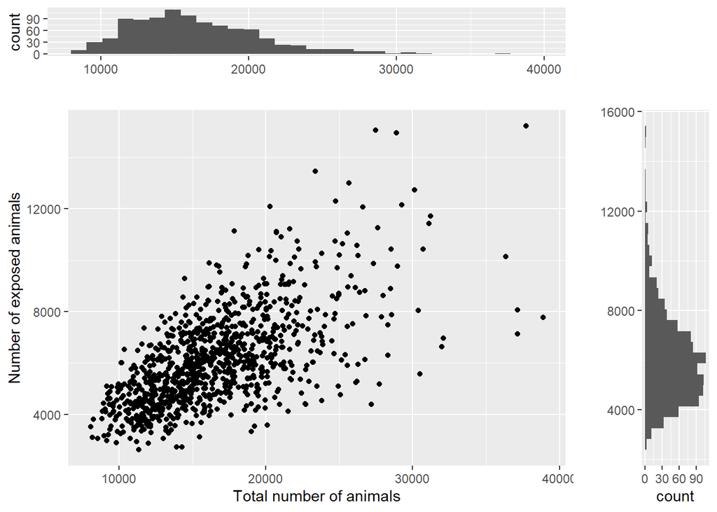

```
## [1] "The proportion of exposed animals against the number of animals in the initial population"
```

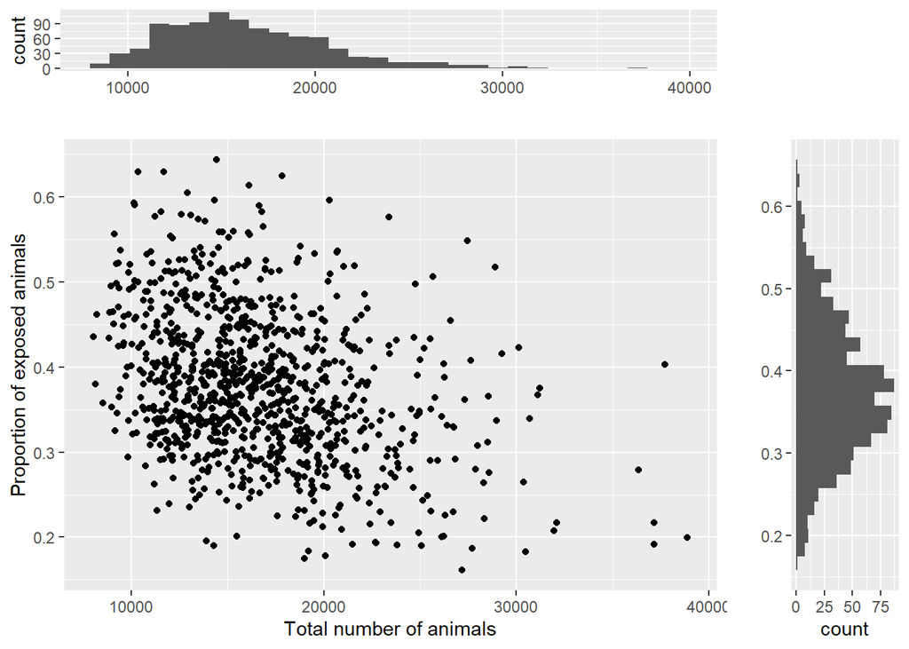

```
## [1] "The following plots are for Ttro"
## [1] "The spatial density for Ttro"
```

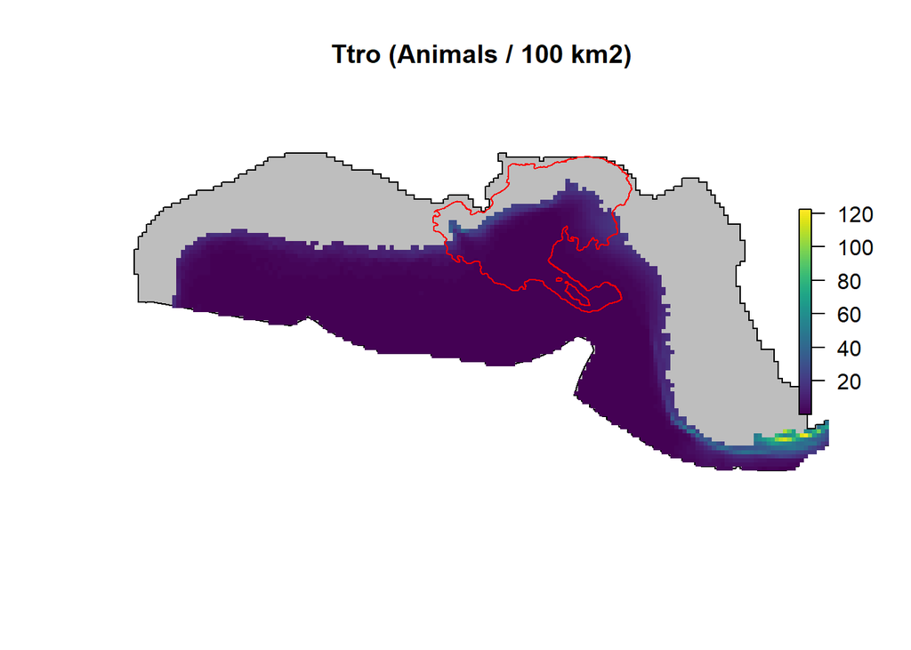

```
## [1] "The number of exposed animals against the number of animals in the initial population"
```

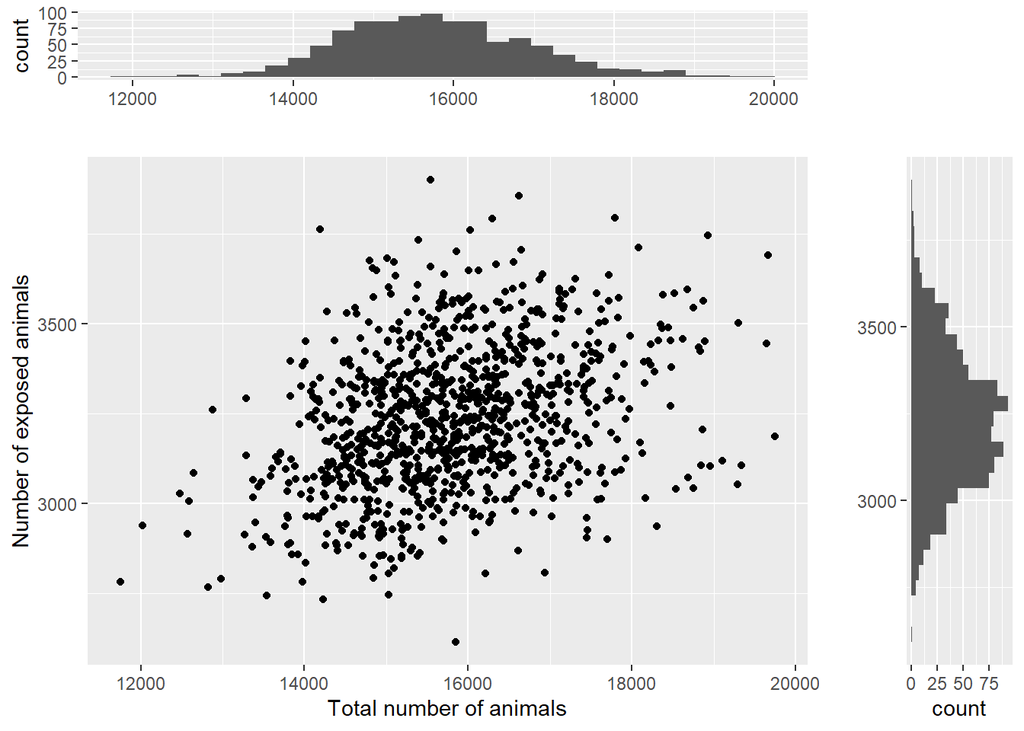

```
## [1] "The proportion of exposed animals against the number of animals in the initial population"
```

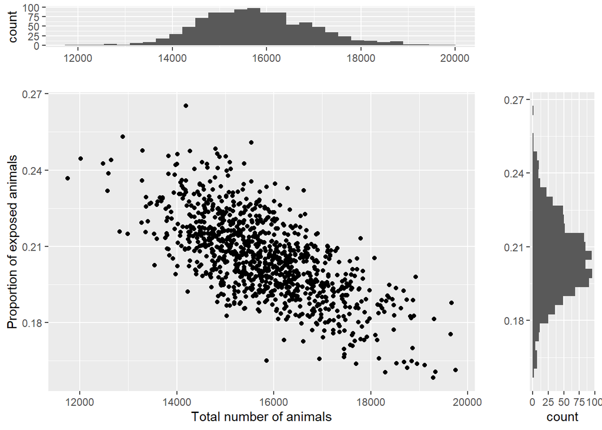

```
## [1] "The following plots are for Ttrs"
## [1] "The spatial density for Ttrs"
```

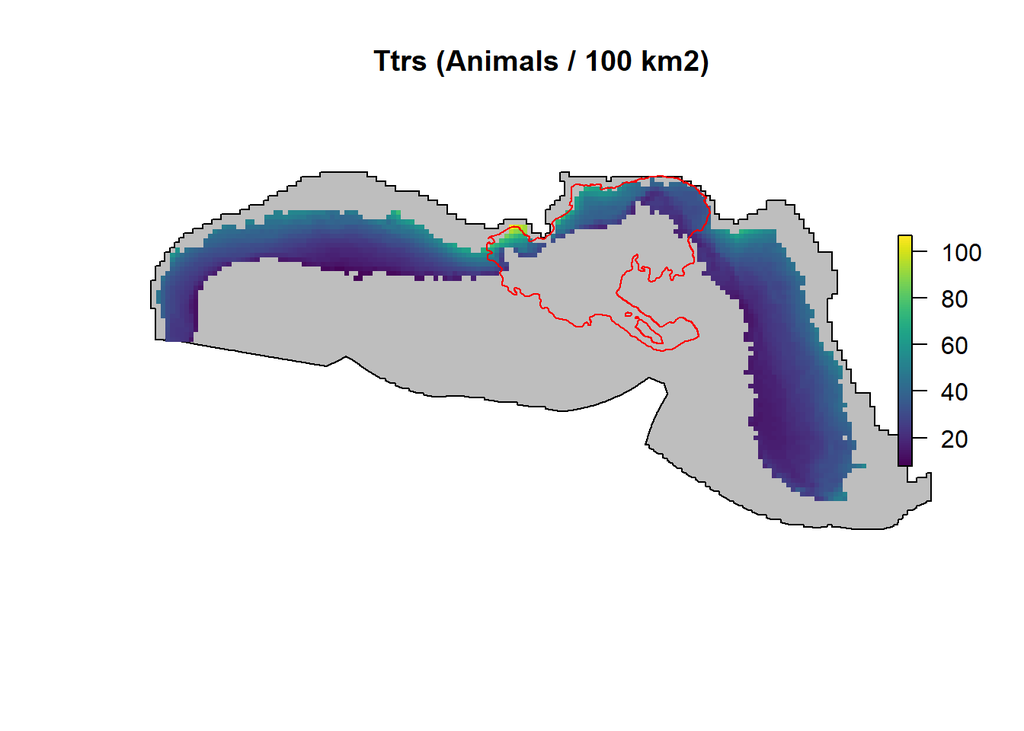

```
## [1] "The number of exposed animals against the number of animals in the initial population"
```

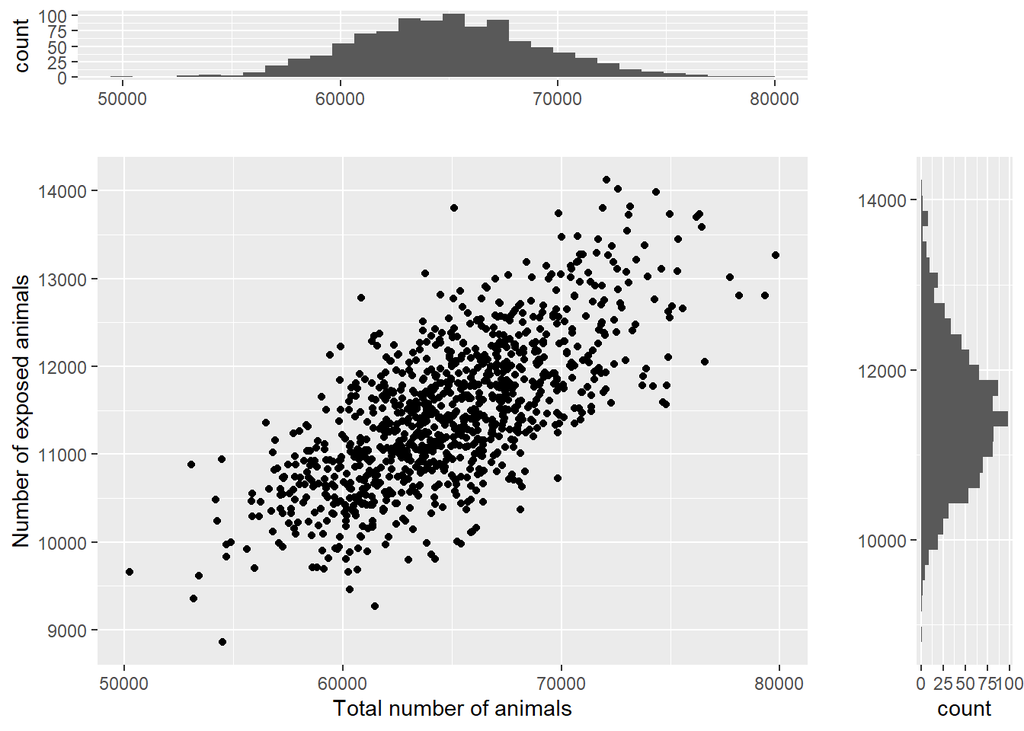

```
## [1] "The proportion of exposed animals against the number of animals in the initial population"
```

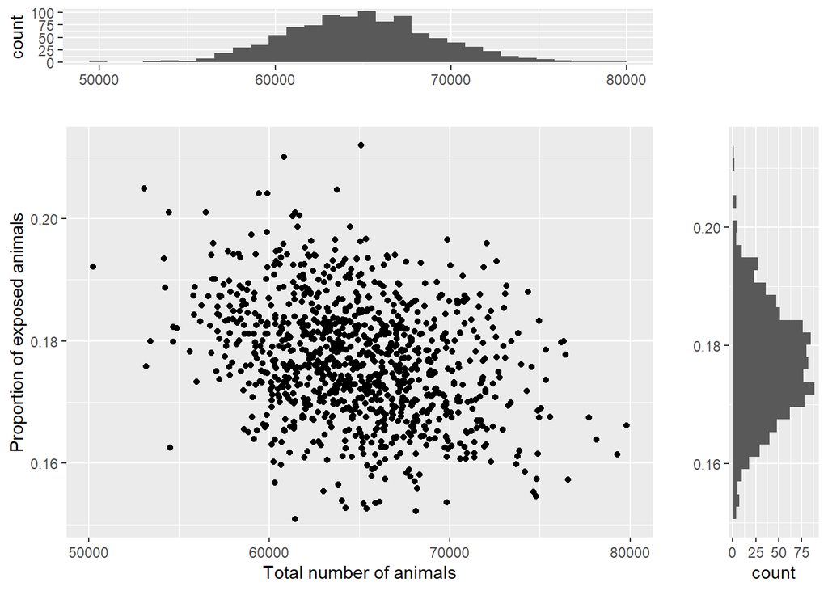

## 3.1 Summary tables

We present below a summary table with the estimated mean for the initial population size (N), the exposed population size (Ne) and the proportion exposed (Pe) for each of the taxonomic units considered. A summary table describing how many iterations were above the limit considered to be unrealistic and caused by GAM extrapolations and hence were removed from the analysis is also presented below.

Estimated mean for the initial population size (N), the exposed population size (Ne) and the proportion exposed (Pe) for each of the taxonomic units considered. The sufix cv, L and U stand for the empirical Coefficient of Variation and Lower and Upper confidence interval bounds. These intervals were obtained by the quantile method.

| Sp | NL | N | NU | Ncv | NeL | Ne | NeU | Necv | PeL | Pe | PeU | Pecv |
| --- | --- | --- | --- | --- | --- | --- | --- | --- | --- | --- | --- | --- |
| Bwsp | 2236 | 3098 | 4323 | 23.2 | 286 | 424 | 604 | 19.1 | 0.093 | 0.140 | 0.191 | 18.5 |
| Fatt | 1137 | 2152 | 3762 | 31.1 | 170 | 310 | 520 | 28.6 | 0.128 | 0.145 | 0.161 | 5.9 |
| Gmac | 1378 | 2065 | 2910 | 18.7 | 146 | 245 | 374 | 24.2 | 0.077 | 0.120 | 0.165 | 19.3 |
| Ggri | 2489 | 3063 | 3759 | 10.6 | 486 | 598 | 730 | 10.8 | 0.154 | 0.197 | 0.248 | 11.9 |
| Kosp | 1650 | 2322 | 3288 | 18.1 | 312 | 458 | 687 | 20.3 | 0.166 | 0.197 | 0.240 | 9.7 |
| Pele | 3483 | 5784 | 9074 | 25.5 | 531 | 879 | 1363 | 24.8 | 0.138 | 0.152 | 0.166 | 4.8 |
| Pmac | 2117 | 2561 | 3094 | 9.5 | 396 | 489 | 595 | 10.3 | 0.168 | 0.191 | 0.216 | 6.4 |
| Satt | 72954 | 81233 | 90464 | 5.5 | 10875 | 12589 | 14353 | 6.9 | 0.142 | 0.155 | 0.168 | 4.2 |
| Sbre | 3271 | 4867 | 6804 | 19.0 | 491 | 720 | 1005 | 18.5 | 0.140 | 0.148 | 0.152 | 2.2 |
| Scly | 6873 | 9065 | 11826 | 14.1 | 474 | 737 | 1087 | 20.4 | 0.054 | 0.082 | 0.113 | 18.6 |
| Scoe | 3579 | 5011 | 6751 | 16.5 | 907 | 1219 | 1588 | 14.6 | 0.174 | 0.247 | 0.323 | 16.0 |
| Sfro | 37527 | 48688 | 62825 | 13.7 | 2150 | 2763 | 3501 | 12.0 | 0.041 | 0.058 | 0.078 | 16.4 |
| Slon | 9589 | 16501 | 27477 | 27.9 | 3411 | 6090 | 10430 | 29.8 | 0.217 | 0.377 | 0.555 | 22.5 |
| Ttro | 13705 | 15791 | 18445 | 7.6 | 2867 | 3232 | 3633 | 6.1 | 0.173 | 0.206 | 0.239 | 7.8 |
| Ttrs | 56992 | 64897 | 73804 | 6.6 | 9943 | 11466 | 13195 | 7.2 | 0.159 | 0.177 | 0.195 | 5.4 |

Treshold value defining extreme realizations and number of realizations considered extreme, for each of the taxonomic units considered.

| Sp | limit | above.limit |
| --- | --- | --- |
| Bwsp | 13210 | 3 |
| Fatt | 5494 | 0 |
| Gmac | 3997 | 0 |
| Ggri | 4684 | 0 |
| Kosp | 4468 | 1 |
| Pele | 13166 | 0 |
| Pmac | 3779 | 0 |
| Satt | 103746 | 0 |
| Sbre | 9486 | 0 |
| Scly | 15565 | 1 |
| Scoe | 9237 | 1 |
| Sfro | 81942 | 0 |
| Slon | 40384 | 2 |
| Ttro | 21756 | 0 |
| Ttrs | 86434 | 0 |

# 4 Producing values for tables in the paper

The following code is used for producing the content for the first table of the main paper, regarding the initial population sizes and proportion exposed (and corresponding precision).

## 4.1 Table 1

### 4.1.1 Initial population sizes

```r
Table1N <-  paste0(round(sumNsPes$N,0),"; ",round(sumNsPes$Ncv,1),
                  " (",round(sumNsPes$NL,0)," ,",round(sumNsPes$NU),")")
#note we remove the last row which has the Ttru for Barataria Bay
write.table(Table1N,"Table1N.txt",sep="\t",row.names = FALSE,quote = FALSE,col.names = FALSE)
```

## 4.2 About the Proportion exposed

```r
Table1P <-  paste0(round(sumNsPes$Pe,3),"; ",round(sumNsPes$Pecv,1),
                  " (",round(sumNsPes$PeL,3)," ,",round(sumNsPes$PeU,3),")")
#note we remove the last row which has the Ttru for Barataria Bay
write.table(Table1P,"Table1P.txt",sep="\t",row.names = FALSE,quote = FALSE,col.names = FALSE)
```

# 5 Additional Tables

The following code is used for producing a table containing the values for initial population size and proportion exposed used as input in the supplementary information file ES5_GetInjury.

```r
write.table(sumNsPes,"Table4GetInjury.txt",sep="\t",
            row.names = FALSE,quote = FALSE,col.names = TRUE)
```

# 6 References

Roberts, J. J.; Best, B. D.; Mannocci, L.; Fujioka, E.; Halpin, P. N.; Palka, D. L.; Garrison, L. P.; Mullin, K. D.; Cole, T. V. N.; Khan, C. B.; McLellan, W. A.; Pabst, D. A. & Lockhart, G. G. 2016 Habitat-based cetacean density models for the U.S. Atlantic and Gulf of Mexico *Scientific Reports* **6**: 22615 DOI: [10.1038/srep22615](https://www.nature.com/articles/srep22615)